# actuaryr-vignette

```r
library(actuaryr)
```

# Date reference functions

## Purpose

Business reports are prepared once a month, once a quarter or once a year. Analysts often compare business results against previous periods. First and last days of a given period are of special significance for reporting.

The `dref_` prefix stands for **d**ate **ref**erence functions. The functions with the `dref_` prefix return a reference date to the chosen date.

## Functions

The functions work within three types of periods:

- a month
- a quarter
- an year

The functions return one of the four types of reference dates:

- the first day
- the first working day
- the last day
- the last working day

The names of functions combine the `dref_` prefix and the first letters of the chosen reference date.

For example, `dref_fdoy()` returns the **f**irst **d**ay **o**f an **y**ear.

The table summarizes all date reference functions.

|  | of month | of quarter | of year |
| --- | --- | --- | --- |
| first day | `dref_fdom()` | `dref_fdoq()` | `dref_fdoy()` |
| first working day | `dref_fwdom()` | `dref_fwdoq()` | `dref_fwdoy()` |
| last day | `dref_ldom()` | `dref_ldoq()` | `dref_ldoy()` |
| last working day | `dref_lwdom()` | `dref_lwdoq()` | `dref_lwdoy()` |

All functions take the argument `date`, which is the base date. The functions return the result in reference to the base date. The functions always work within a specific period: a month, a quarter or an year.

### Monthly periods

The base date has been marked with orange.

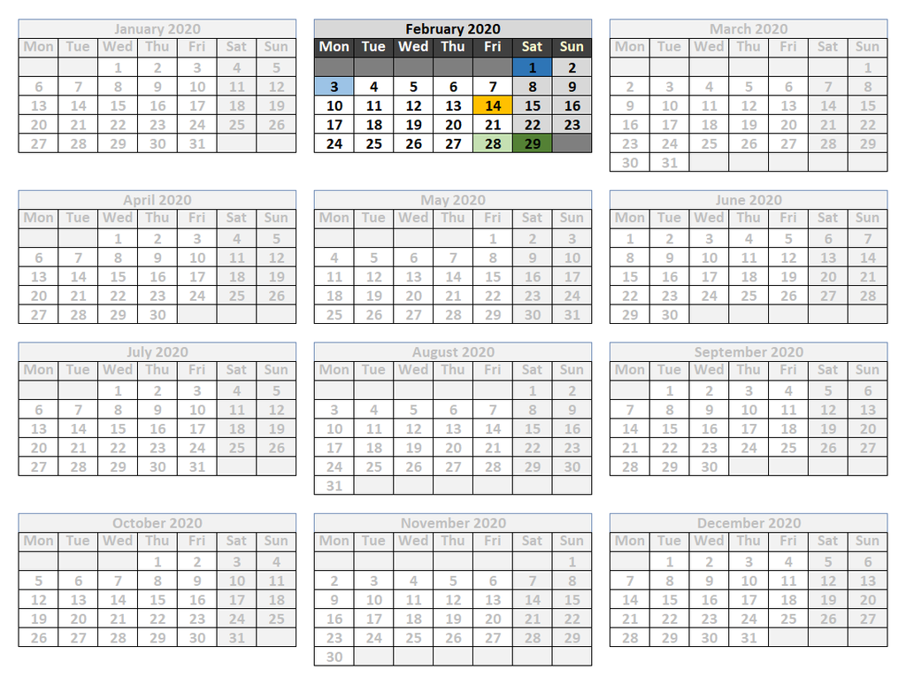

### Quarterly periods

The reference dates in the image below can be retrieved with the following functions:

- `dref_fdoq()` - dark blue
- `dref_fwdoq()` - light blue
- `dref_ldoq()` - light green
- `dref_lwdoq()` - dark green

The base date has been marked with orange.

**Watch out!** The first day of a year is the same as the first working day of a year. The last day of a year is the same as the last working day of a year. Hence, the same day is marked with two colors (darker and lighter).

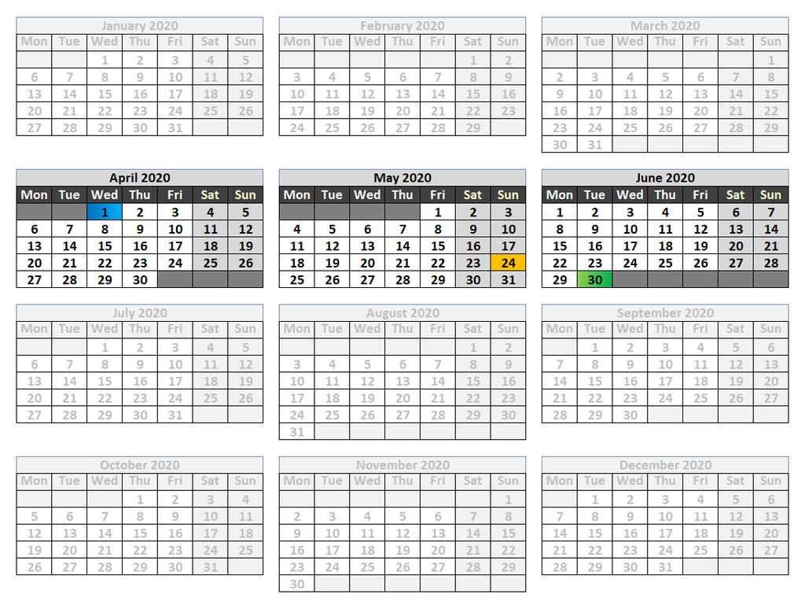

### Yearly periods

The reference dates in the image below can be retrieved with the following functions:

- `dref_fdoy()` - dark blue
- `dref_fwdoy()` - light blue
- `dref_ldoy()` - light green
- `dref_lwdoy()` - dark green

The base date has been marked with orange.

**Watch out!** The first day of a year is the same as the first working day of a year. The last day of a year is the same as the last working day of a year. Hence, the same day is marked with two colors (darker and lighter).

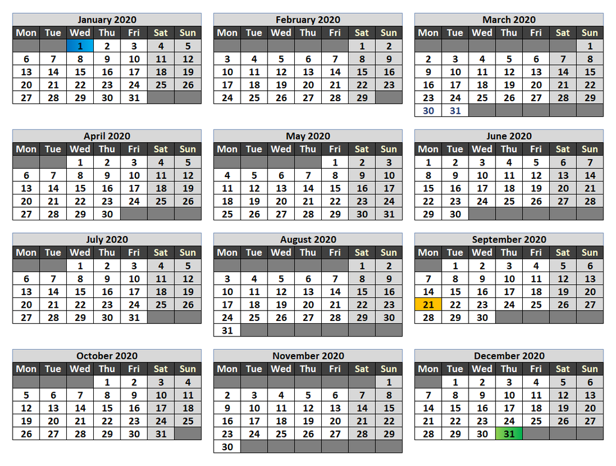